# Titanic

Sholah

2022-10-15

```r
library(tidyverse)
```

```r
library(ggplot2)
library(ggpie)
```

[figure not shown]

```r
knitr::include_graphics("titanicsink.jpg")
```

# 1 INTRODUCTION

here we will explore the data about the passengers of a renowed boat, RMS Titanic. At the end of this project, we might unfold some facts about its passengers through this document. For the start, let’s import the data!

# 2 PREPARING THE DATA

```r
tnc <- read.csv("Titanic.csv")
```

```r
dim(tnc)
```

```
## [1] 418  12
```

```r
head(tnc)
```

| PassengerId | Survived | Pclass | Name | Sex | Age | SibSp | Parch | Ticket | Fare | Cabin | Embarked |
| --- | --- | --- | --- | --- | --- | --- | --- | --- | --- | --- | --- |
| 892 | 0 | 3 | Kelly, Mr. James | male | 34.5 | 0 | 0 | 330911 | 7.8292 |  | Q |
| 893 | 1 | 3 | Wilkes, Mrs. James (Ellen Needs) | female | 47.0 | 1 | 0 | 363272 | 7.0000 |  | S |
| 894 | 0 | 2 | Myles, Mr. Thomas Francis | male | 62.0 | 0 | 0 | 240276 | 9.6875 |  | Q |
| 895 | 0 | 3 | Wirz, Mr. Albert | male | 27.0 | 0 | 0 | 315154 | 8.6625 |  | S |
| 896 | 1 | 3 | Hirvonen, Mrs. Alexander (Helga E Lindqvist) | female | 22.0 | 1 | 1 | 3101298 | 12.2875 |  | S |
| 897 | 0 | 3 | Svensson, Mr. Johan Cervin | male | 14.0 | 0 | 0 | 7538 | 9.2250 |  | S |

```r
tail(tnc)
```

|  | PassengerId | Survived | Pclass | Name | Sex | Age | SibSp | Parch | Ticket | Fare | Cabin | Embarked |
| --- | --- | --- | --- | --- | --- | --- | --- | --- | --- | --- | --- | --- |
| 413 | 1304 | 1 | 3 | Henriksson, Miss. Jenny Lovisa | female | 28.0 | 0 | 0 | 347086 | 7.7750 |  | S |
| 414 | 1305 | 0 | 3 | Spector, Mr. Woolf | male | NA | 0 | 0 | A.5. 3236 | 8.0500 |  | S |
| 415 | 1306 | 1 | 1 | Oliva y Ocana, Dona. Fermina | female | 39.0 | 0 | 0 | PC 17758 | 108.9000 | C105 | C |
| 416 | 1307 | 0 | 3 | Saether, Mr. Simon Sivertsen | male | 38.5 | 0 | 0 | SOTON/O.Q. 3101262 | 7.2500 |  | S |
| 417 | 1308 | 0 | 3 | Ware, Mr. Frederick | male | NA | 0 | 0 | 359309 | 8.0500 |  | S |
| 418 | 1309 | 0 | 3 | Peter, Master. Michael J | male | NA | 1 | 1 | 2668 | 22.3583 |  | C |

## 2.1 Scrutinizing the data types

```r
str(tnc)
```

```
## 'data.frame':    418 obs. of  12 variables:
##  $ PassengerId: int  892 893 894 895 896 897 898 899 900 901 ...
##  $ Survived   : int  0 1 0 0 1 0 1 0 1 0 ...
##  $ Pclass     : int  3 3 2 3 3 3 3 2 3 3 ...
##  $ Name       : chr  "Kelly, Mr. James" "Wilkes, Mrs. James (Ellen Needs)" "Myles, Mr. Thomas Francis" "Wirz, Mr. Albert" ...
##  $ Sex        : chr  "male" "female" "male" "male" ...
##  $ Age        : num  34.5 47 62 27 22 14 30 26 18 21 ...
##  $ SibSp      : int  0 1 0 0 1 0 0 1 0 2 ...
##  $ Parch      : int  0 0 0 0 1 0 0 1 0 0 ...
##  $ Ticket     : chr  "330911" "363272" "240276" "315154" ...
##  $ Fare       : num  7.83 7 9.69 8.66 12.29 ...
##  $ Cabin      : chr  "" "" "" "" ...
##  $ Embarked   : chr  "Q" "S" "Q" "S" ...
```

```r
str(tnc)
```

```
## 'data.frame':    418 obs. of  12 variables:
##  $ PassengerId: int  892 893 894 895 896 897 898 899 900 901 ...
##  $ Survived   : int  0 1 0 0 1 0 1 0 1 0 ...
##  $ Pclass     : int  3 3 2 3 3 3 3 2 3 3 ...
##  $ Name       : chr  "Kelly, Mr. James" "Wilkes, Mrs. James (Ellen Needs)" "Myles, Mr. Thomas Francis" "Wirz, Mr. Albert" ...
##  $ Sex        : chr  "male" "female" "male" "male" ...
##  $ Age        : num  34.5 47 62 27 22 14 30 26 18 21 ...
##  $ SibSp      : int  0 1 0 0 1 0 0 1 0 2 ...
##  $ Parch      : int  0 0 0 0 1 0 0 1 0 0 ...
##  $ Ticket     : chr  "330911" "363272" "240276" "315154" ...
##  $ Fare       : num  7.83 7 9.69 8.66 12.29 ...
##  $ Cabin      : chr  "" "" "" "" ...
##  $ Embarked   : chr  "Q" "S" "Q" "S" ...
```

## 2.2 Check if there is any missing value

```r
anyNA(tnc)
```

```
## [1] TRUE
```

```r
colSums(is.na(tnc))
```

```
## PassengerId    Survived      Pclass        Name         Sex         Age
##           0           0           0           0           0          86
##       SibSp       Parch      Ticket        Fare       Cabin    Embarked
##           0           0           0           1           0           0
```

## 2.3 Putting out the missing value off the table

```r
tnc <- na.exclude(tnc)
dim(tnc)
```

```
## [1] 331  12
```

## 2.4 Summarizing the data

```r
summary(tnc)
```

```
##   PassengerId        Survived          Pclass          Name
##  Min.   : 892.0   Min.   :0.0000   Min.   :1.000   Length:331
##  1st Qu.: 992.5   1st Qu.:0.0000   1st Qu.:1.000   Class :character
##  Median :1100.0   Median :0.0000   Median :2.000   Mode  :character
##  Mean   :1100.2   Mean   :0.3837   Mean   :2.142
##  3rd Qu.:1210.5   3rd Qu.:1.0000   3rd Qu.:3.000
##  Max.   :1307.0   Max.   :1.0000   Max.   :3.000
##      Sex                 Age            SibSp            Parch
##  Length:331         Min.   : 0.17   Min.   :0.0000   Min.   :0.0000
##  Class :character   1st Qu.:21.00   1st Qu.:0.0000   1st Qu.:0.0000
##  Mode  :character   Median :27.00   Median :0.0000   Median :0.0000
##                     Mean   :30.18   Mean   :0.4834   Mean   :0.3988
##                     3rd Qu.:39.00   3rd Qu.:1.0000   3rd Qu.:1.0000
##                     Max.   :76.00   Max.   :8.0000   Max.   :6.0000
##     Ticket               Fare           Cabin             Embarked
##  Length:331         Min.   :  0.00   Length:331         Length:331
##  Class :character   1st Qu.:  8.05   Class :character   Class :character
##  Mode  :character   Median : 16.00   Mode  :character   Mode  :character
##                     Mean   : 40.98
##                     3rd Qu.: 40.63
##                     Max.   :512.33
```

## 2.5 Checking the unique of each column

```r
sapply(tnc, n_distinct)
```

```
## PassengerId    Survived      Pclass        Name         Sex         Age
##         331           2           3         331           2          78
##       SibSp       Parch      Ticket        Fare       Cabin    Embarked
##           7           7         284         148          73           3
```

```r
unique(tnc$Survived)
```

```
## [1] 0 1
```

```r
unique(tnc$Pclass)
```

```
## [1] 3 2 1
```

```r
unique(tnc$Sex)
```

```
## [1] "male"   "female"
```

```r
unique(tnc$Embarked)
```

```
## [1] "Q" "S" "C"
```

Here are some facts and explanation about the data

1. PassengerId is unique for each passenger, there won’t be any similar passenger id
2. Survived contains 2 category. 0 = not survived, 1 = survived
3. Pclass is passenger class
4. Name, Sex, Age are what they are
5. SibSp is the total of siblings on board on the RMS Titanic
6. Parch is the total of parents/children on board on the RMS Titanic
7. Ticket is the distinctive id for each ticket, or ticket number
8. Fare is the ticket price. the mean for the ticket price is 40.98 dollar and the most expensive ticket charges at 512.33 dollar
9. Cabin is the number of Cabin the passenger stayed at (if they were in Cabin)
10. Embarked is the port of Embarkation. C = Cherbourg, Q = Queenstown; S = Southampton

Now, I will remove the columns: SibSp, Parch, as it does not tell much the relation between each variables or observations

```r
tnc <- tnc[,-c(7:8)]
names(tnc)
```

```
##  [1] "PassengerId" "Survived"    "Pclass"      "Name"        "Sex"
##  [6] "Age"         "Ticket"      "Fare"        "Cabin"       "Embarked"
```

# 3 3. DATA VISUALIZATION

```r
head(tnc)
```

| PassengerId | Survived | Pclass | Name | Sex | Age | Ticket | Fare | Cabin | Embarked |
| --- | --- | --- | --- | --- | --- | --- | --- | --- | --- |
| 892 | 0 | 3 | Kelly, Mr. James | male | 34.5 | 330911 | 7.8292 |  | Q |
| 893 | 1 | 3 | Wilkes, Mrs. James (Ellen Needs) | female | 47.0 | 363272 | 7.0000 |  | S |
| 894 | 0 | 2 | Myles, Mr. Thomas Francis | male | 62.0 | 240276 | 9.6875 |  | Q |
| 895 | 0 | 3 | Wirz, Mr. Albert | male | 27.0 | 315154 | 8.6625 |  | S |
| 896 | 1 | 3 | Hirvonen, Mrs. Alexander (Helga E Lindqvist) | female | 22.0 | 3101298 | 12.2875 |  | S |
| 897 | 0 | 3 | Svensson, Mr. Johan Cervin | male | 14.0 | 7538 | 9.2250 |  | S |

## 3.1 Proportion of Males and Females On Board

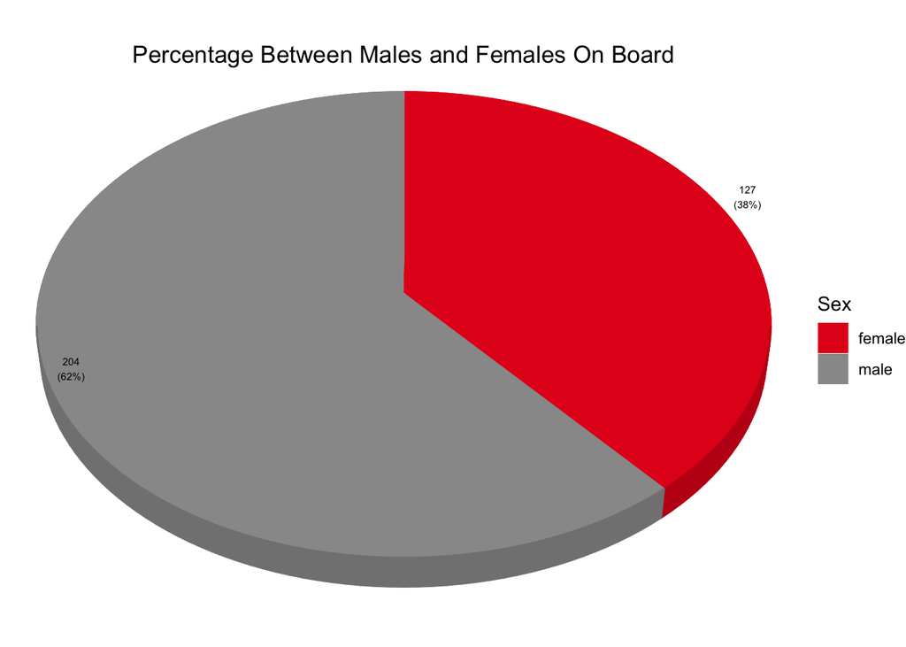

```r
ggpie3D(data = tnc, group_key = "Sex",
        count_type = "full",
        tilt_degrees = 8,
        label_size=2) +
  ggtitle("Percentage Between Males and Females On Board") +
  theme(plot.title = element_text(hjust = 0.5))
```

The total of males and females recorded in the data, there are 62% of male with the total of 204 passengers, and 38% females with the total of 127 passengers

## 3.2 Ticket per Class

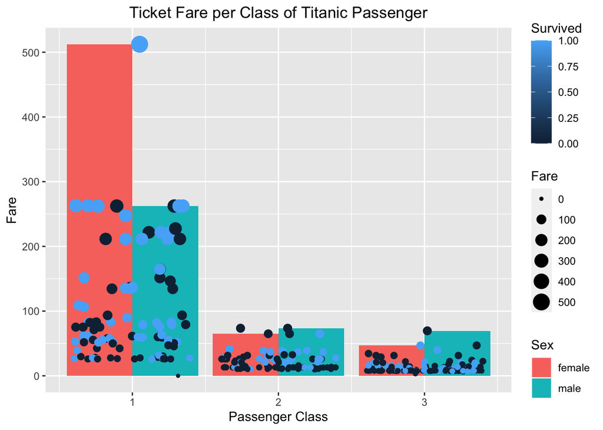

```r
ggplot(tnc, aes(Pclass, Fare))+
  geom_col(aes(fill= Sex), position = "dodge")+
  geom_jitter(aes(col=Survived, size=Fare))+
  labs(title = "Ticket Fare per Class of Titanic Passenger",
       x = "Passenger Class")+
  theme(plot.title = element_text(hjust = 0.5))
```

```r
filter(tnc, Pclass == 1, Fare == 0)
```

| PassengerId | Survived | Pclass | Name | Sex | Age | Ticket | Fare | Cabin | Embarked |
| --- | --- | --- | --- | --- | --- | --- | --- | --- | --- |
| 1264 | 0 | 1 | Ismay, Mr. Joseph Bruce | male | 49 | 112058 | 0 | B52 B54 B56 | S |

the free rider of a first class ticket is Mr. Joseph Bruce Ismay, which was probably the owner, special guest, or the important crew of the RMS Titanic

## 3.3 Passenger’s Age In Each Sex

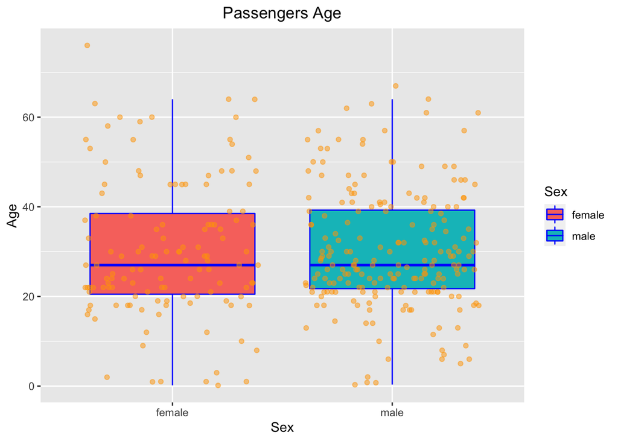

```r
ggplot(tnc, aes(Sex, Age))+
  geom_boxplot(outlier.shape=NA, aes(fill=Sex), col="Blue")+
  geom_jitter(alpha=0.5, col="orange")+
  labs(title = "Passengers Age")+
  theme(plot.title = element_text(hjust = 0.5))
```

from the data above we can see that:

1. the most, second-most, and third-most passengers’ age for both sex fall in between the age of 20-40, 41-60, and 0-20 respectively
2. there are babies on board
3. the oldest male passenger is under 70
4. the oldest female passenger is above 70
5. the average age for both sex is almost the same

## 3.4 Proportion of Passenger Survived Grouped Based on Sex

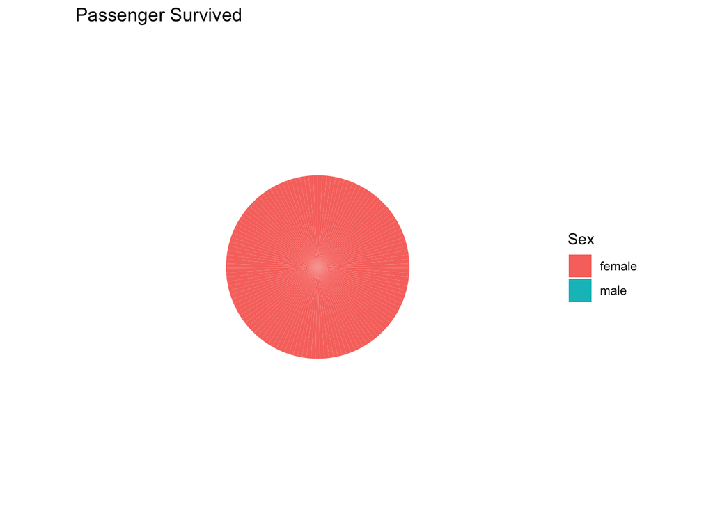

```r
ggplot(tnc, aes(Sex, Survived))+
  labs(title = "Passenger Survived",
       x = "Sex",
       y = "Survived")+
  geom_bar(stat = "identity", aes(fill= Sex))+
  coord_polar("y", start=0, direction = 1)+
  theme_void()
```

as we can see from the pie chart above that all survived passengers of Titanic accident are female. To prove it, let’s see it through the table.

```r
filter(tnc, Survived == 1, Sex == "male")
```

| PassengerId | Survived | Pclass | Name | Sex | Age | Ticket | Fare | Cabin | Embarked |
| --- | --- | --- | --- | --- | --- | --- | --- | --- | --- |

```r
filter(tnc, Survived == 0, Sex == "female")
```

| PassengerId | Survived | Pclass | Name | Sex | Age | Ticket | Fare | Cabin | Embarked |
| --- | --- | --- | --- | --- | --- | --- | --- | --- | --- |

from the data above, we can conclude that all females recorded in the data are survived the accident, and all males recorded in the data are not survived the accident.

## 3.5 Percentage of Embarkation In Each Port

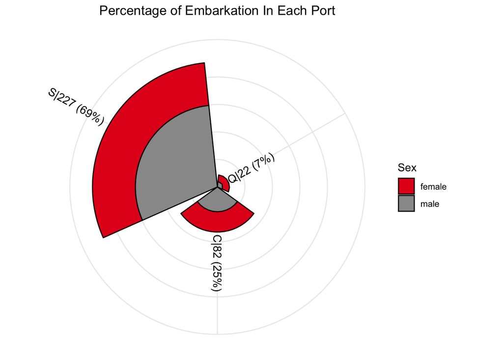

```r
ggrosepie(data = tnc, group_key = c("Embarked", "Sex"),
          count_type = "full",
          label_info = "all",
          show_tick = F,
          donut_frac = NULL,
          donut_label_size = "5") +
  ggtitle("Percentage of Embarkation In Each Port") +
  theme(plot.title = element_text(hjust = 0.5))
```

[figure not shown]

```r
ggplot(tnc, aes(Embarked, Sex))+
  geom_col(aes(fill = Sex), position = "fill",
           show.legend = F)+
  labs(title = "Proportion Based On Sex In Each Embarkation Port",
       x = "Passenger Class")+
  theme(plot.title = element_text(hjust = 0.5))
```

from 2 graphs depicted above, the data show that :

1. Port Southampton has the highest embarkation with the total of 69% total passengers, with majority of males
2. Port Cherbourg has the second highest of embarkation with the total of 25% total passengers, with majority of males
3. Port Queesntown has the least total passengers embarkation with the total of 7%. However, the proportion of females between port is the highest in this port

## 3.6 Proportion of Males And Females In Each Class

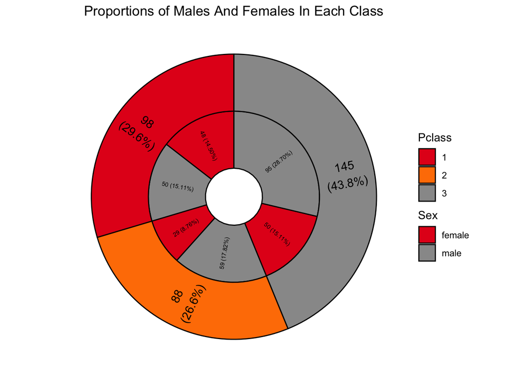

```r
ggnestedpie(tnc, group_key = c("Pclass", "Sex"), count_type = "full",
            inner_label_info = "all",
            inner_label_split = NULL,
            inner_label_size = 2,
            outer_label_type = "circle",
            outer_label_pos = "in",
            outer_label_info = "all")+
  labs(title = "Proportions of Males And Females In Each Class")+
  theme(plot.title = element_text(hjust=0.5))
```

From the Nested Pie Chart above we can see that:

1. The proportion of 1st class is the second highest which standing at 29.6% total passengers of all classes, with proportion of males is 15.11% and females is 14.50% of all passengers in all classes
2. The proportion of 2nd class is the least, standing at 26.6% total passengers of all classes, with proportion of males is 17.82% and females is 8.76% of all passengers in all classes
3. The proportion of 3rd class is the majority of all passengers come from which is 43.8% total passengers of all classes, with proportion of males is 28.70% and females is 15.11% of all passengers in all classes